# graphs

vishnusagar2021

2/7/2021

# R base

##pie chart in pie(x,labels, radius, main, col, clockwise)

x= vector lables = discription to the vectors radius = -1 to +1 main = title of chart col= color for chart colockwise = clockwise and anticlockwise T/F

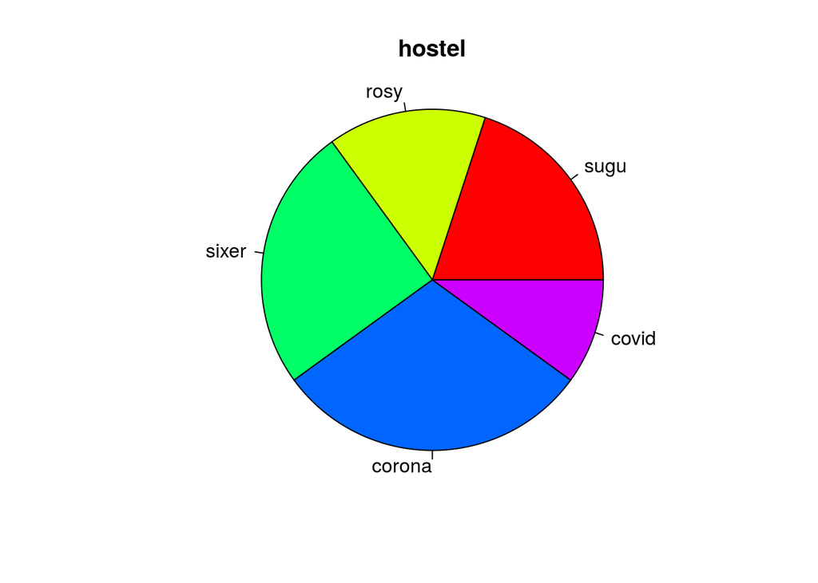

```r
#eg
x= c(20,15,25,30,10)

labels= c("sugu","rosy","sixer","corona","covid")

#eg1

pie(x,labels, radius = 1,main = "hostel",col=rainbow (5), colockwise = F)
```

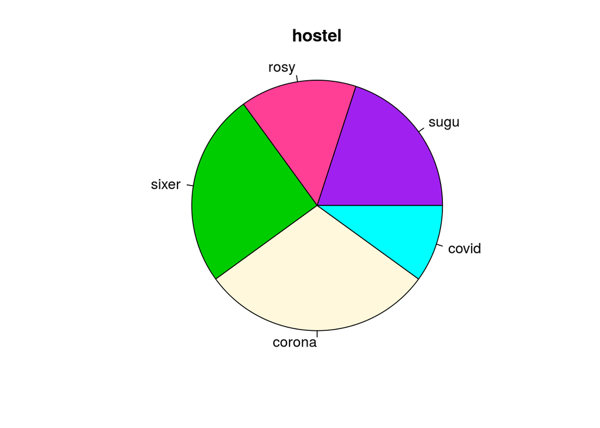

```r
#eg2

pie(x,labels, radius = 1,main = "hostel",col=c("purple", "violetred1", "green3",
"cornsilk", "cyan", "white"), colockwise = F)
```

```r
#eg3
```

##saving a graph/diagram 1) x= c(20,15,25,30,10)…………………………data for graph

labels= c(“sugu”,“rosy”,“sixer”,“corona”,“covid”)

2. png(file=“filename.png”)…………….chart file name
3. pie(x,labels, radius = 1,main = “hostel”,col=rainbow (5), colockwise = F)
4. dev.off() …………..for svaing the file ``

```r
x= c(20,15,25,30,10)
labels= c("sugu","rosy","sixer","corona","covid")
png(file= "hostel.png")
pie (x,labels, radius = 1,main = "hostel", col=rainbow (5))

dev.off()
```

#percentage pie

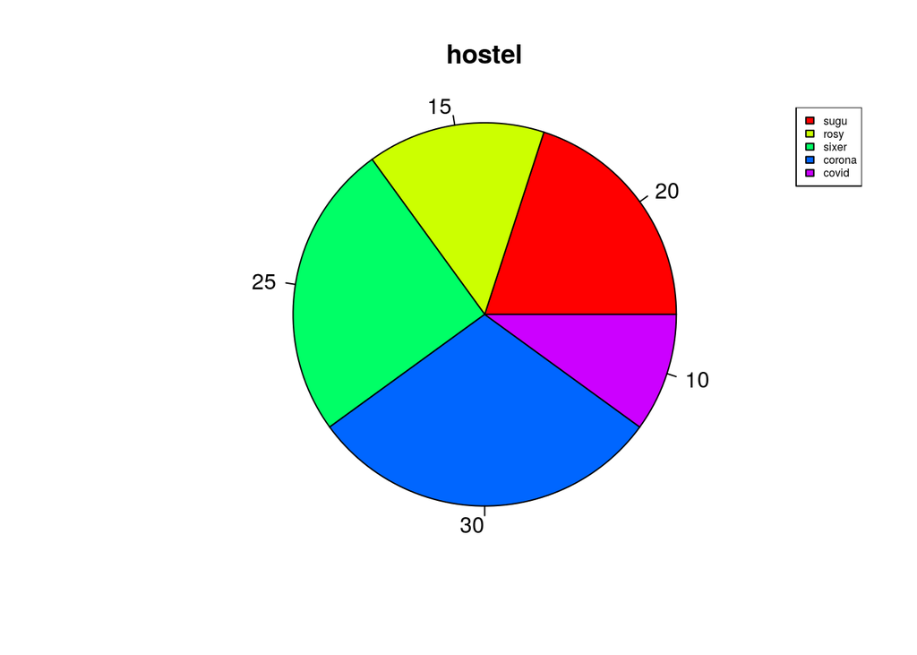

```r
piepercent=round(100*x/sum(x),1)
pie(x,labels=piepercent, radius = 1,main = "hostel", col=rainbow(length(x)))
legend("topright", c("sugu","rosy","sixer","corona","covid"), cex=0.5, fill=rainbow(length(x)))
```

##3D pie chart library(“plotrix”)

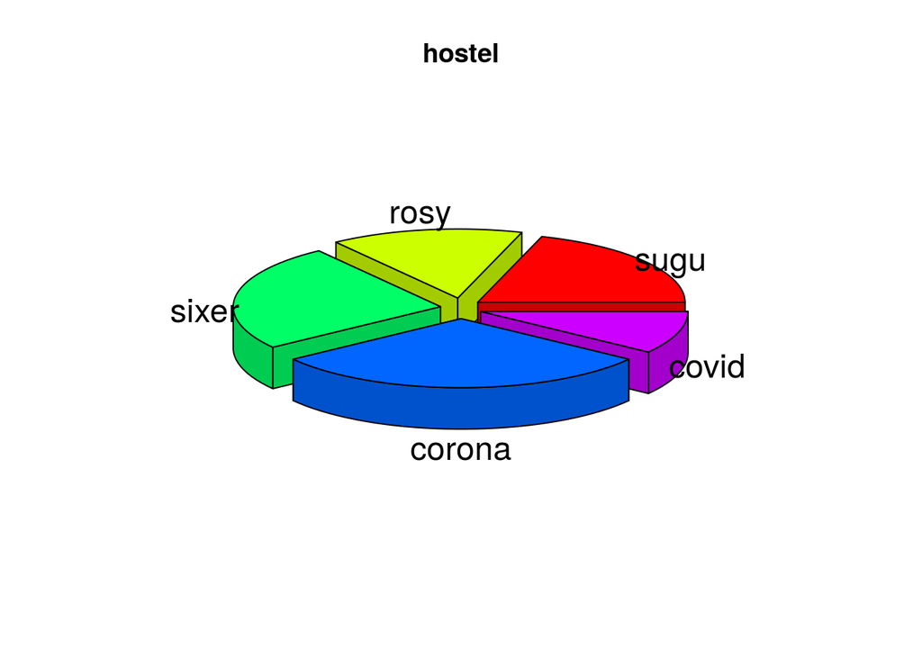

```r
install.packages("plotrix")
library("plotrix")
pie3D(x,labels=labels, explode=0.1, main = "hostel")
```

#Bar diagaram barplot(H,xlab,ylab,main,names.arg, col) H-data xlab- x axis label ylab- y axis label main - chart title names.arg- vecor containing names for each bar col- color for bar

```r
png(file="bar.png")
H=c(8,12,9,11,6)
label= c("S1","S2","S3","S4","S5")
barplot(H, xlab = "stations",ylab = "TDS(mg/L)", names.arg = label,col= "blue", border = "black")
dev.off()
```

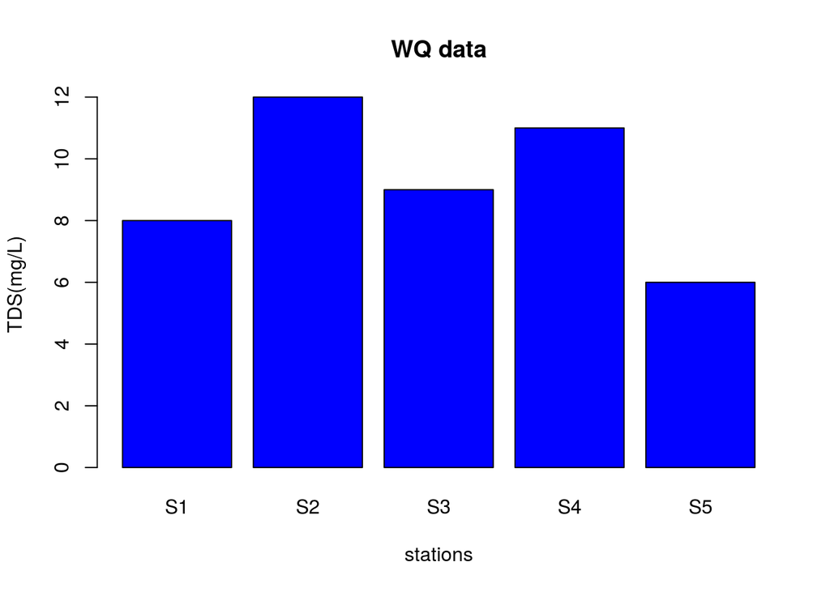

```r
H=c(8,12,9,11,6)
label= c("S1","S2","S3","S4","S5")
barplot(H, xlab = "stations",ylab = "TDS(mg/L)", main= "WQ data", names.arg = label,col= "blue", border = "black")
```

#group bar chart and stacked barchart

```r
colors= c("blue","green", "red")
Station= c("S1","S2","S3","S4","S5")
quality= c("good","bad", "poor")

values=matrix(c(20:34),nrow=3, ncol=5, byrow=T)
values
```

```
##      [,1] [,2] [,3] [,4] [,5]
## [1,]   20   21   22   23   24
## [2,]   25   26   27   28   29
## [3,]   30   31   32   33   34
```

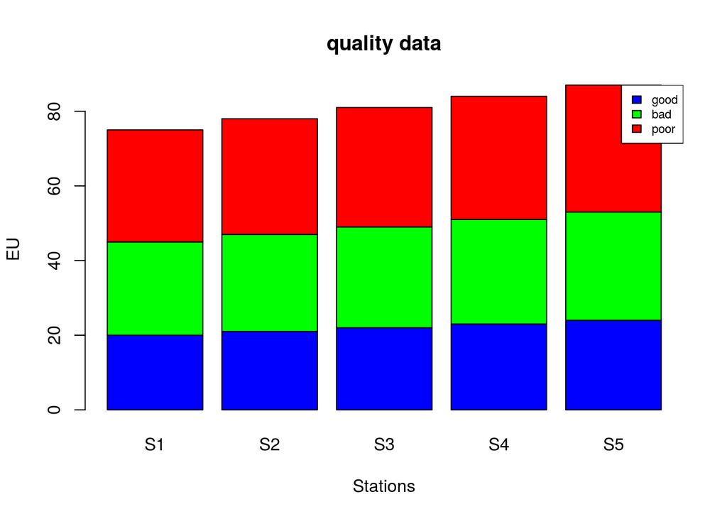

```r
barplot(values,xlab = "Stations", ylab="EU", main="quality data", names.arg = Station, col=colors, border= "black")
legend("topright",quality, cex= 0.7, fill=colors)
```

```r
colors= c("blue","green", "red")
Station= c("S1","S2","S3","S4","S5")
quality= c("good","bad", "poor")

values=matrix(c(20:34),nrow=3, ncol=5, byrow=T)
values
```

```
##      [,1] [,2] [,3] [,4] [,5]
## [1,]   20   21   22   23   24
## [2,]   25   26   27   28   29
## [3,]   30   31   32   33   34
```

```r
png(file="group_bar.png")
barplot(values,xlab = "Stations", ylab="EU", main="quality data", names.arg = Station, col=colors, border= "black")
legend("topright",quality, cex= 0.7, fill=colors)
dev.off()
```

# Histogram

hist(V,main=,xlab=,xlim=,ylim=,breaks=,col=, border=)

v- vector data main - title of diagram xlab- labels of x axis xlim- limt of x ylim- limt of y breaks= bar numbers or width of bar

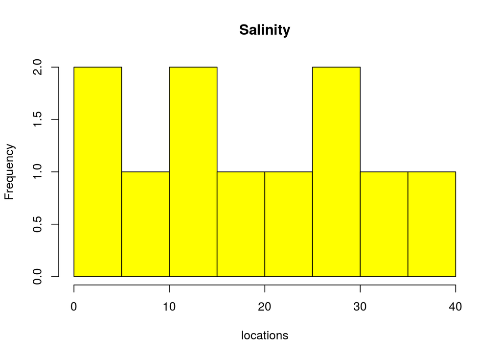

```r
v=c(2,5,8,11,15,18,22,26,30,34,39)

hist(v,main = "Salinity",xlab = "locations", col= "yellow",breaks = 8, border="black")
```

## xlim & ylim in histogram

```r
v=c(2,5,8,11,15,18,22,26,30,34,39)
png(file="histogram.png")
hist(v,main = "Salinity",xlab = "locations",xlim=c(0,40), ylim= c(0,3), col= "yellow",breaks = 8, border="black")
dev.off()
```

##Line graph plot(v,type,col,xlab,ylab) v- data vector type- “p” only points, “l” only lines, “o” both lines and ponits

xlab- labels of x axis ylab- lables for y axis col - colors

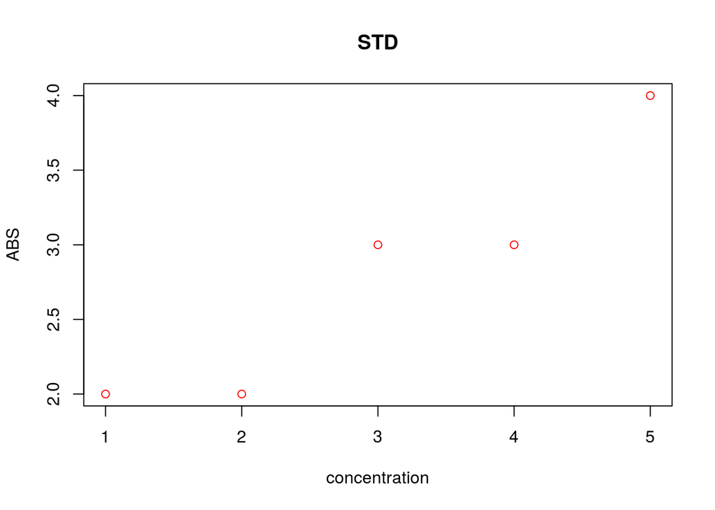

```r
v=as.integer(c(2.2,2.8, 3.5,3.9, 4.2))
plot(v,type="p",xlab="concentration",ylab = "ABS",col="red",main = "STD")
```

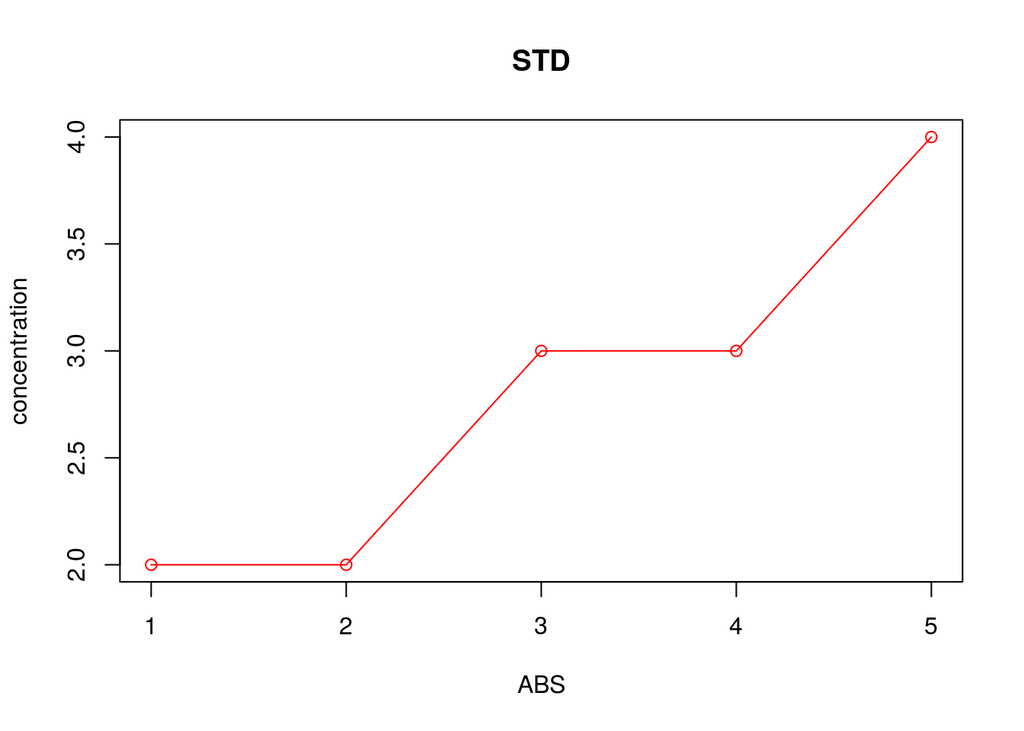

```r
plot(v,type="o",xlab="ABS",ylab = "concentration",col="red",main = "STD")
```

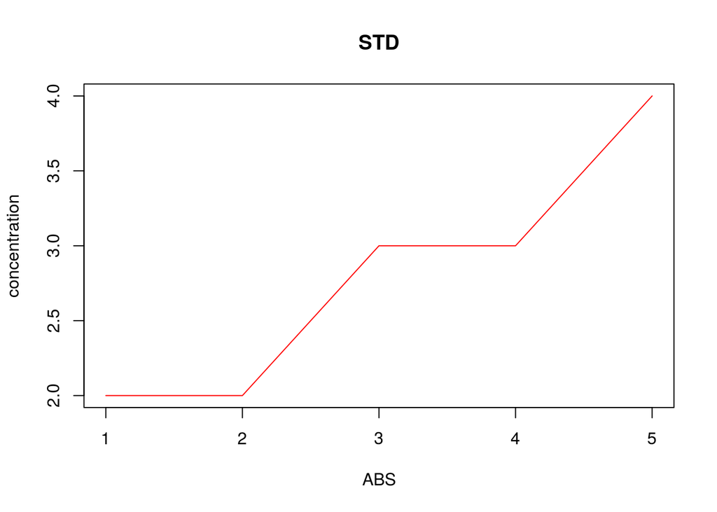

```r
plot(v,type="l",xlab="ABS",ylab = "concentration",col= "red",main = "STD")
```

#multiple plot

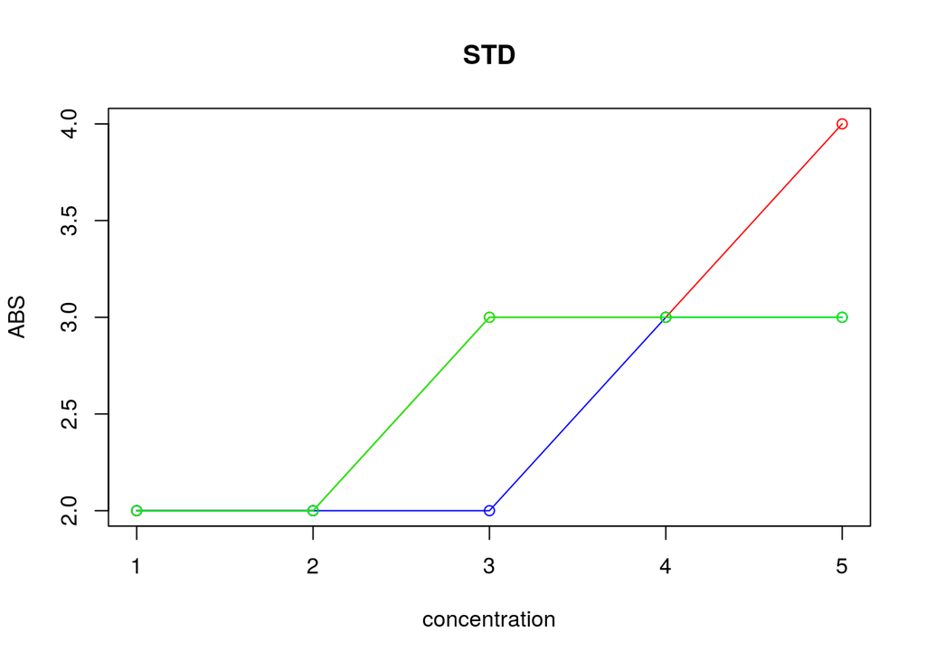

```r
v=as.integer(c(2.2,2.8, 3.5,3.9, 4.2))
p=as.integer(c(2.0,2.1, 2.8,3.2, 3.8))
q=as.integer(c(2.4,2.6, 3.2,3.6, 3.9))

plot(v,type="o",xlab="concentration",ylab = "ABS",col="red",main = "STD")
lines(p,type="o",col="blue")
lines(q,type="o",col="green")
```

```r
# xlim and ylim not allowed here
```

```r
v=as.integer(c(2.2,2.8, 3.5,3.9, 4.2))
p=as.integer(c(2.0,2.1, 2.8,3.2, 3.8))
q=as.integer(c(2.4,2.6, 3.2,3.6, 3.9))
png(file="linegraph.png")
plot(v,type="o",xlab="concentration",ylab = "ABS",col="red",main = "STD")
lines(p,type="o",col="blue")
lines(q,type="o",col="green")
dev.off()
```

## R-Scatter plot

plot(x,y,main=,xlab=,ylab=xlim=,ylim=,axes=)

x- vector1 y- vector 2

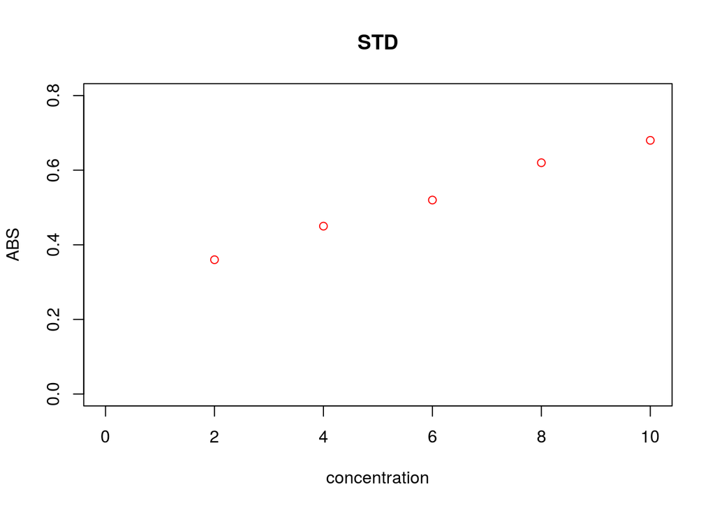

```r
x= c(2,4,6,8,10)
y=c(0.36,0.45,0.52,0.62,0.68)

plot(x,y,main="STD",xlab="concentration",ylab="ABS",xlim= c(0,10), ylim=c(0,0.80), col="red")
```

#Data visualization with ggplot

```r
library("ggplot2")

# bar diagram

head(mtcars)
```

```
##                    mpg cyl disp  hp drat    wt  qsec vs am gear carb
## Mazda RX4         21.0   6  160 110 3.90 2.620 16.46  0  1    4    4
## Mazda RX4 Wag     21.0   6  160 110 3.90 2.875 17.02  0  1    4    4
## Datsun 710        22.8   4  108  93 3.85 2.320 18.61  1  1    4    1
## Hornet 4 Drive    21.4   6  258 110 3.08 3.215 19.44  1  0    3    1
## Hornet Sportabout 18.7   8  360 175 3.15 3.440 17.02  0  0    3    2
## Valiant           18.1   6  225 105 2.76 3.460 20.22  1  0    3    1
```

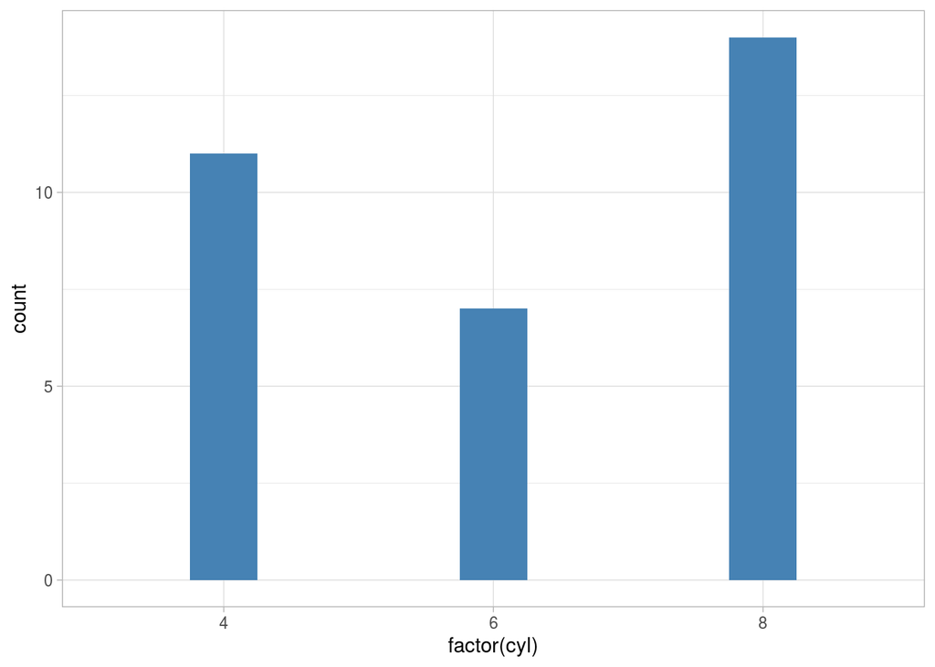

```r
p=ggplot(data= mtcars,aes(x=factor(cyl)))+
  geom_bar(stat="count",width=0.25, fill="steelblue")+
  theme_light()
p
```

```r
png(file= "ggplot_bar.png")

head(mtcars)
```

```
##                    mpg cyl disp  hp drat    wt  qsec vs am gear carb
## Mazda RX4         21.0   6  160 110 3.90 2.620 16.46  0  1    4    4
## Mazda RX4 Wag     21.0   6  160 110 3.90 2.875 17.02  0  1    4    4
## Datsun 710        22.8   4  108  93 3.85 2.320 18.61  1  1    4    1
## Hornet 4 Drive    21.4   6  258 110 3.08 3.215 19.44  1  0    3    1
## Hornet Sportabout 18.7   8  360 175 3.15 3.440 17.02  0  0    3    2
## Valiant           18.1   6  225 105 2.76 3.460 20.22  1  0    3    1
```

```r
p=ggplot(data= mtcars,aes(x=factor(cyl)))+
  geom_bar(stat="count",width=0.25, fill="steelblue")+
  theme_light()
p
dev.off()
```

```r
# Change barplot line colors by groups
head(mtcars)
```

```
##                    mpg cyl disp  hp drat    wt  qsec vs am gear carb
## Mazda RX4         21.0   6  160 110 3.90 2.620 16.46  0  1    4    4
## Mazda RX4 Wag     21.0   6  160 110 3.90 2.875 17.02  0  1    4    4
## Datsun 710        22.8   4  108  93 3.85 2.320 18.61  1  1    4    1
## Hornet 4 Drive    21.4   6  258 110 3.08 3.215 19.44  1  0    3    1
## Hornet Sportabout 18.7   8  360 175 3.15 3.440 17.02  0  0    3    2
## Valiant           18.1   6  225 105 2.76 3.460 20.22  1  0    3    1
```

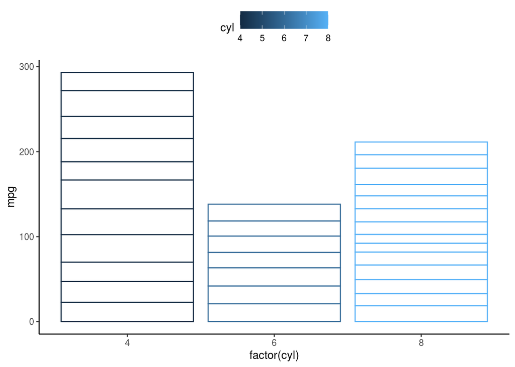

```r
p=ggplot (mtcars,aes(x=factor(cyl), y=mpg, color=cyl))+
  geom_bar(stat="identity", fill="white")+
  theme_classic()+
  theme(legend.position = "top")
p
```

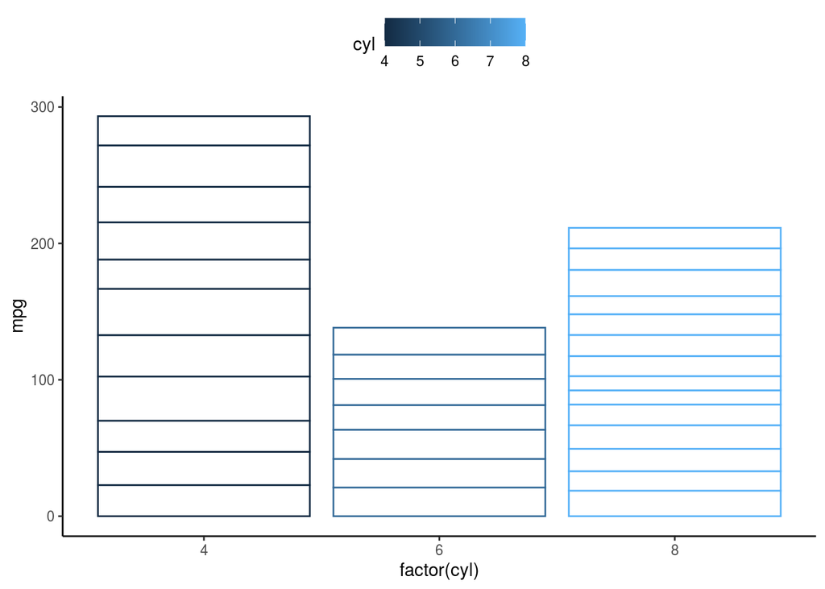

```r
p = p+scale_fill_brewer(palette="Blues")
p + theme(legend.position="top")
```

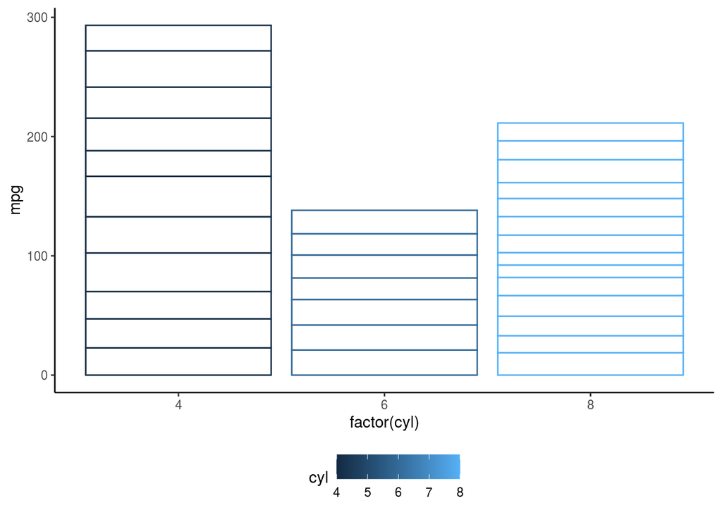

```r
p + theme(legend.position="bottom")
```

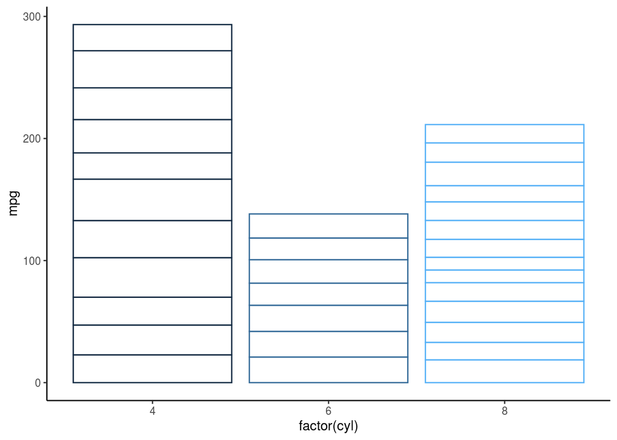

```r
# Remove legend
p + theme(legend.position="none")
```

### Barplot with multiple groups

```r
df2 <- data.frame(supp=rep(c("VC", "OJ"), each=3),
                dose=rep(c("D0.5", "D1", "D2"),2),
                len=c(6.8, 15, 33, 4.2, 10, 29.5))
head(df2)
```

```
##   supp dose  len
## 1   VC D0.5  6.8
## 2   VC   D1 15.0
## 3   VC   D2 33.0
## 4   OJ D0.5  4.2
## 5   OJ   D1 10.0
## 6   OJ   D2 29.5
```

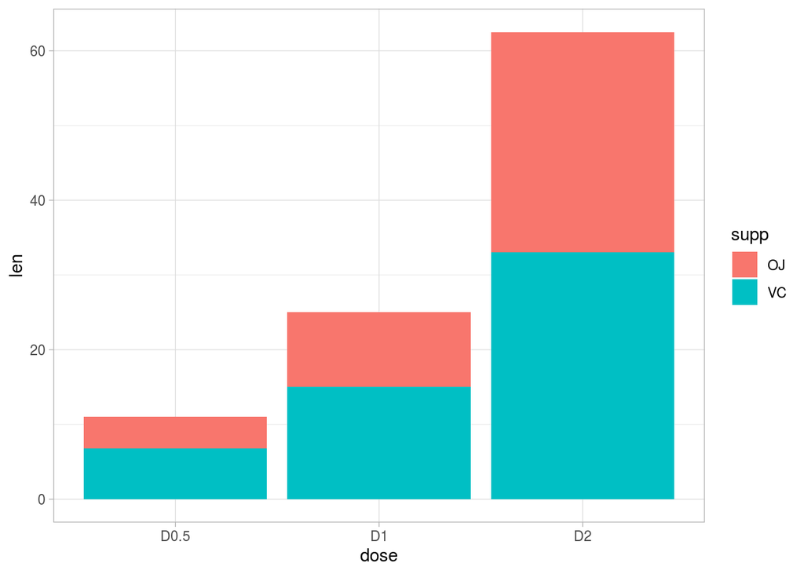

```r
ggplot(data=df2, aes(x=dose, y=len, fill=supp)) +
  geom_bar(stat="identity") +
  theme_light()
```

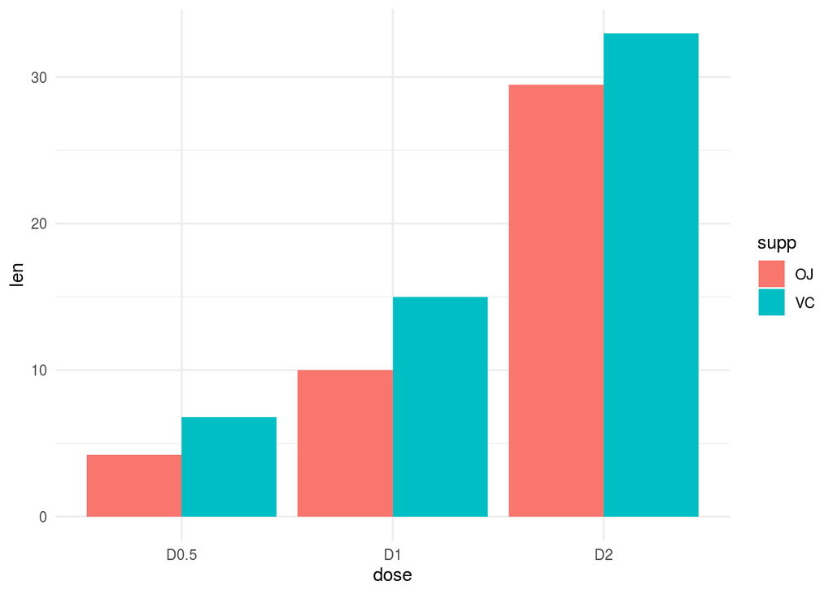

```r
ggplot(data=df2, aes(x=dose, y=len, fill=supp)) +
geom_bar(stat="identity", position = position_dodge() )+
  theme_minimal()
```

```r
install.packages("xlsx")
library("xlsx")
```

```r
data001= read.xlsx ("/cloud/project/vishnudata/WQ_data_003.xlsx", sheetIndex = 1)
head(data001)
```

```
##    season Location  pH EC..µS.cm. TDS..ppm. DO..mg.L. BOD..mg.L. TA..mg..
## 1 Season1       S1 7.5      48.33     24.08       4.2      1.136      100
## 2 Season1       S2 7.8      72.29     34.96       4.0      1.520       50
## 3 Season1       S3 7.2      90.37     49.14       3.4      6.732       50
## 4 Season1       S4 7.0      74.30     35.48       3.5      6.930       50
## 5 Season1       S5 7.4      81.17     37.98       3.6      7.128       50
## 6 Season1       S6 7.7     111.50     62.46       3.2      6.336      100
##   TH..mg.L. Na..mg.. Cl..mg.L. NH4.N..mg.L. NO3.N..mg.L. NO2.N..mg.L.
## 1        12     3.20     21.30         0.12       0.3300         0.05
## 2         8     4.36     28.36         0.22       0.5925         0.06
## 3         8     4.20     42.55         0.18       0.6050         0.09
## 4        12     5.54     32.46         0.17       0.6900         0.04
## 5        16     7.21     34.80         0.13       0.6475         0.05
## 6        16     5.93     52.55         0.16       0.5700         0.06
##   PO4.P..mg.. SiO3..mg.. TP..mg.. Chlorophyll.a.
## 1        0.13       0.47     0.21           5.89
## 2        0.15       0.65     0.23           1.53
## 3        0.22       0.72     0.31           1.74
## 4        0.24       0.83     0.35           2.99
## 5        0.27       1.14     0.38           2.66
## 6        0.28       0.98     0.40           3.42
```

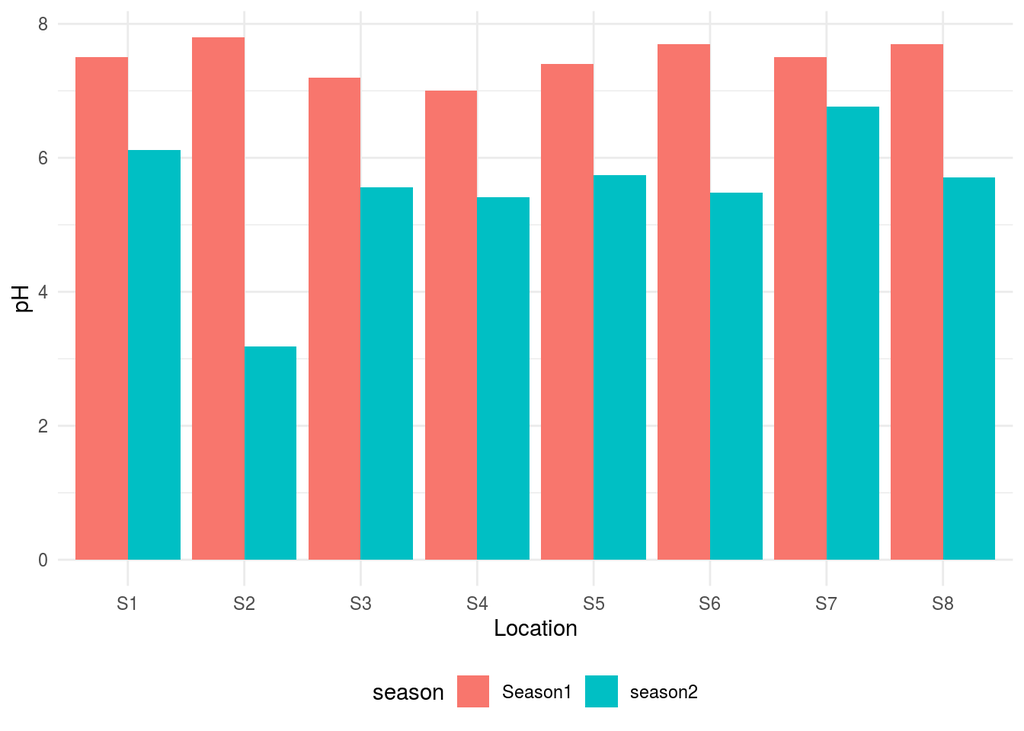

```r
ggplot(data=data001, aes(x=Location, y=pH, fill=season)) +
geom_bar(stat="identity", position = position_dodge())+
  theme_minimal()+theme(legend.position="bottom")
```